# Predecir la supervivencia de los árboles

Juan de Dios Castillo Calleja

Carlos Diepa Santana

María José Zamorano Poblete

[figure not shown]

[figure not shown]

### Introducción

En kaggle, se nos ha proporcionado la información de un estudio de la supervivencia de tres especies del género *Acer*, en el cual se estudiaron diferentes factores que podían influir en su supervivencia. Aquí se nos proporcionaba la base de datos del experimento, la información que aportaron los autores, y el artículo que se publicó analizando estos datos, que contenía más información sobre lo que se hizo. Por esto, sabemos que los datos están compuestos por 19 columnas que incluyen:

- **No:** Identificador de las semillas.
- **Species** Especies utilizadas, capaces de vivir en el mismo entorno, pero con diferente tolerancia a la luz. Las especies son:
  - Acsa = *Acer saccharum*
  - Acru = *Acer rubrum*
  - Acne = *Acer negundo*
- **Light:** Niveles de luz utilizados en el experimento. Los niveles son:
  - Low = 2% luz directa
  - High = 30% luz directa
- **Microbe:** Microorganismos utilizados, se obtuvo un filtrado de estos y se aplicaron, obteniéndose cinco tratamientos, que fueron:
  - Control: papel de filtro esterilizado.
  - None: agua desionizada y papel de filtro.
  - Small: 20 µm filtrado en agua desionizada y papel de filtro.
  - Large: agua desionizada y 40-250 µm filtrado en papel de filtro.
  - Combined: Small + Large, es decir, el filtrado estaba tanto en agua desionizada como en papel de filtro.
- **Adult:** Número de árboles adultos que se utilizaron para recoger el suelo donde plantaron las semillas.
- **Bench:** Número de la maceta donde se cultivó cada semilla.
- **Harvest:** En qué semana fue cosechada la plántula para medir los datos. Pueden ser **3**, **6** o **9 semanas**.
- **Time:** Día del experimento en el que la planta se cosechó, murió o terminó el experimento.
- **Event:** Para analizar la supervivencia de las plántulas. Cada una se caracterizó como:
  - 0 = utilizada en el experimento.
  - 1 = muerta.
- **AMF:** Porcentaje de colonización por los microorganismos. Calculado son los datos *AMFcount/AMFintersections*. Se basa en el número de colonias contadas en las raíces, en 100 intersecciones.
- **Phenolics:** Calculado como nmol de ácido gálico equivalentes por mg de peso seco.
- **NSC:** Calculado como porcentaje de peso seco compuesto por carbohidratos no estructurales.
- **Lignin:** Porcentaje de masa seca que corresponde a la lignina.
- **AMF_Imp:** Valores de *AMF* imputados.
- **PHN_Imp:** Valores de *Phenolics* imputados.
- **NSC_Imp:** Valores de *NSC* imputados.
- **LIG_Imp:** Valores de *Lignin* imputados.

Lo primero que hicimos fue visualizar los datos que habíamos obtenido. Para esto, creamos una variable donde leímos el archivo proporcionado, que tenía la extensión **“.csv”**. A la variable la llamamos: **tree_survival**.

Posteriormente, tras haber obtenido la variable, analizamos la información de nuestro dataset. Para ello, averiguamos la dimensión y clase de nuestros datos. Tras conocer esto, vamos a ver la información relevante de los mismos.

La base de datos del experimento es un *data.frame* y sus dimensiones son de **2400 filas** y **19 columnas**. Al comparar estas dimensiones, vemos que tiene 2400 observaciones, mientras que en el artículo nos habla de 1920. Al ver que tenemos datos imputados, conocemos entonces que hay datos perdidos en el dataframe, por lo que vamos a visualizar la información de cada columna.

```r
summary(tree_survival)
```

```
##        No           Species             Light             Microbe
##  Min.   :   1.0   Length:2400        Length:2400        Length:2400
##  1st Qu.: 600.8   Class :character   Class :character   Class :character
##  Median :1200.5   Mode  :character   Mode  :character   Mode  :character
##  Mean   :1200.5
##  3rd Qu.:1800.2
##  Max.   :2400.0
##
##      Adult            Bench        Harvest         Time           Event
##  Min.   : 1.000   Min.   :1.0   Min.   :3     Min.   :15.00   Min.   :0.0000
##  1st Qu.: 3.000   1st Qu.:2.0   1st Qu.:3     1st Qu.:21.00   1st Qu.:0.0000
##  Median : 6.000   Median :3.5   Median :6     Median :42.00   Median :0.0000
##  Mean   : 5.998   Mean   :3.5   Mean   :6     Mean   :44.66   Mean   :0.2608
##  3rd Qu.: 9.000   3rd Qu.:5.0   3rd Qu.:9     3rd Qu.:63.00   3rd Qu.:1.0000
##  Max.   :11.000   Max.   :6.0   Max.   :9     Max.   :63.00   Max.   :1.0000
##  NA's   :480                    NA's   :600
##     AMFCount      AMFIntersections      AMF           Phenolics
##  Min.   :  0.00   Min.   : 41.00   Min.   :  0.00   Min.   :-0.5100
##  1st Qu.:  0.00   1st Qu.:100.00   1st Qu.:  0.00   1st Qu.: 0.0000
##  Median :  1.00   Median :100.00   Median :  0.00   Median : 0.1300
##  Mean   : 24.73   Mean   : 98.38   Mean   : 25.11   Mean   : 0.1331
##  3rd Qu.: 56.00   3rd Qu.:100.00   3rd Qu.: 58.75   3rd Qu.: 0.2600
##  Max.   :100.00   Max.   :100.00   Max.   :100.00   Max.   : 0.7100
##  NA's   :1510     NA's   :1510     NA's   :1510     NA's   :1510
##       NSC            Lignin          AMF_Imp          PHN_Imp
##  Min.   : 0.24   Min.   : 1.190   Min.   :  0.00   Min.   :-0.4100
##  1st Qu.: 7.52   1st Qu.: 5.930   1st Qu.:  0.57   1st Qu.: 0.0200
##  Median :10.40   Median : 8.140   Median : 25.02   Median : 0.1500
##  Mean   :10.25   Mean   : 8.562   Mean   : 32.48   Mean   : 0.1657
##  3rd Qu.:12.79   3rd Qu.:11.047   3rd Qu.: 64.89   3rd Qu.: 0.3000
##  Max.   :22.61   Max.   :19.170   Max.   :100.00   Max.   : 0.7100
##  NA's   :1509    NA's   :1510     NA's   :480      NA's   :480
##     NSC_Imp          LIG_Imp
##  Min.   : 0.440   Min.   : 1.190
##  1st Qu.: 7.968   1st Qu.: 6.997
##  Median :10.040   Median : 8.225
##  Mean   :10.137   Mean   : 8.812
##  3rd Qu.:12.315   3rd Qu.:11.102
##  Max.   :22.610   Max.   :19.170
##  NA's   :480      NA's   :480
```

A partir de aquí, vamos a obtener el dataframe que se utilizó en el experimento, es decir, el que más observaciones tiene (1920). En primer lugar, vamos a instalar los paquetes necesarios que utilizaremos posteriormente. Comenzamos instalando los paquetes.

Cuando ya los tengo instalados, procedo a cargar los paquetes.

Para obtener informacion hemos utilizado el articulo *Tree seedling shade tolerance arises from interactions with microbes and is mediated by functional traits* (Wood, Kobe, and McCarthy-Neumann 2023).Hemos utilizado los paquetes **dplyr** (Wickham et al. 2023), **R** (R Core Team 2024), **ggplot2** (Wickham 2016; Wickham et al. 2024), **knitr** (Xie 2024, 2015, 2014) y **tidyverse** (Wickham et al. 2019). Para realizar las pruebas estadísticas, hemos utilizado paquetes nuevos que no se dieron en clase. Los hemos instalado porque nos permiten realizar otras pruebas estadísticas que nos son de utilidad con nuestros datos. Con el paquete **vegan** (Oksanen et al. 2024) usamos, por ejemplo, la función **adonis2** para hacer **PERMANOVAS** y con el paquete **tseries** (Trapletti and Hornik 2024) utilizamos la prueba de normalidad **Jarque-Bera**. Además utilizamos el paquete **stats**, (con funciones cómo **shapiro.test** y **wilcox.test**) que ya viene preinstalado y cargado en R.

Tengo ya los paquetes que serán de utilidad, por lo que ahora obtengo mi dataframe procesado.

### Obtención del dataframe

Al visualizar la información de cada columna, vemos que hay variables en las que tenemos 1510 datos perdidos, de ahí que se hayan hecho los valores imputados. Analizando las columnas y la cantidad de valores perdidos, hemos eliminado los valores no imputados y hemos seleccionado las variables que serán de utilidad posteriormente. Las variables seleccionadas son las que menos valores perdidos tienen, para así filtrar nuestro dataframe y eliminar las observaciones que tienen datos perdidos. Para conseguir esto, hicimos varias pruebas, de las cuales indicaremos con la que obtuvimos el dataframe de 1920 observaciones.

```
##    Species             Light             Microbe              Bench
##  Length:2400        Length:2400        Length:2400        Min.   :1.0
##  Class :character   Class :character   Class :character   1st Qu.:2.0
##  Mode  :character   Mode  :character   Mode  :character   Median :3.5
##                                                           Mean   :3.5
##                                                           3rd Qu.:5.0
##                                                           Max.   :6.0
##
##       Time           Event           AMF_Imp          PHN_Imp
##  Min.   :15.00   Min.   :0.0000   Min.   :  0.00   Min.   :-0.4100
##  1st Qu.:21.00   1st Qu.:0.0000   1st Qu.:  0.57   1st Qu.: 0.0200
##  Median :42.00   Median :0.0000   Median : 25.02   Median : 0.1500
##  Mean   :44.66   Mean   :0.2608   Mean   : 32.48   Mean   : 0.1657
##  3rd Qu.:63.00   3rd Qu.:1.0000   3rd Qu.: 64.89   3rd Qu.: 0.3000
##  Max.   :63.00   Max.   :1.0000   Max.   :100.00   Max.   : 0.7100
##                                   NA's   :480      NA's   :480
##     NSC_Imp          LIG_Imp
##  Min.   : 0.440   Min.   : 1.190
##  1st Qu.: 7.968   1st Qu.: 6.997
##  Median :10.040   Median : 8.225
##  Mean   :10.137   Mean   : 8.812
##  3rd Qu.:12.315   3rd Qu.:11.102
##  Max.   :22.610   Max.   :19.170
##  NA's   :480      NA's   :480
```

Debemos de tener ya el dataframe sin datos perdidos, nuestro data frame actual tiene: **1920 observaciones** y **10 variables**. Comprobamos si hay datos perdidos en el dataframe.

```
##   Species          Light          Microbe          Bench
##  Mode :logical   Mode :logical   Mode :logical   Mode :logical
##  FALSE:1920      FALSE:1920      FALSE:1920      FALSE:1920
##     Time           Event          AMF_Imp         PHN_Imp
##  Mode :logical   Mode :logical   Mode :logical   Mode :logical
##  FALSE:1920      FALSE:1920      FALSE:1920      FALSE:1920
##   NSC_Imp         LIG_Imp
##  Mode :logical   Mode :logical
##  FALSE:1920      FALSE:1920
```

Tras esto observamos que no poseemos datos perdidos en ninguna variable y, por tanto, tenemos nuestro dataframe definitivo. Lo guardamos con una extension **.csv** para utilizarlo posteriormente, leyendo directamente este dataframe.

### Hipótesis

Leyendo el artículo asociado a los datos, hemos obtenido varias hipótesis, las cuales, trataremos de comprobar estadísticamente. Estas hipótesis nos ayudarán a saber porque algunas de las plantas pueden llegar a sobrevivir en mayor proporción en condiciones de poca luz y que factores influyen en esto:

- **Hipótesis 1**: Existe una relación entre las concentraciones de **fenoles** y carbohidratos no estructurales (**NSC**) y la supervivencia de las plantas en sombra.
- **Hipótesis 2**: Los **AMF** producen en la planta un aumento en la concentración de **NSC**, y los microorganismos patógenos, un aumento en la concentración de fenoles.

### Hipótesis 1

#### Hipótesis 1.1

Como en el caso de *Event*, los datos están como 0 y 1, modificamos esa columna para obtener como datos “Vivo” y “Muerto”, en el caso de que sea necesario para una variable, también filtramos los datos para que sólo nos de las plantas crecidas en sombra, ya que sólo en estas condiciones los fenoles y NSCs suponen una supuesta ventaja en la supervivencia.

```
##   PHN_Imp NSC_Imp Event Light
## 1   -0.05    5.64 Alive   Low
## 2   -0.01    6.37 Alive   Low
## 3    0.03    7.65  Dead   Low
## 4    0.00    8.02 Alive   Low
## 5    0.13   11.11 Alive   Low
## 6    0.21   10.68 Alive   Low
```

```r
DeadPHN <- hipo1 %>% transmute (Dead = if_else(Event == "Dead", PHN_Imp, NA)) %>%
  drop_na()
glimpse(DeadPHN)
```

```
## Rows: 266
## Columns: 1
## $ Dead <dbl> 0.03, 0.02, 0.03, 0.02, 0.02, 0.03, 0.03, -0.02, -0.01, -0.01, 0.…
```

```r
AlivePHN <- hipo1 %>% transmute (Alive = if_else(Event == "Alive", PHN_Imp, NA)) %>%
  drop_na()
glimpse(AlivePHN)
```

```
## Rows: 694
## Columns: 1
## $ Alive <dbl> -0.05, -0.01, 0.00, 0.13, 0.21, 0.08, -0.04, 0.21, 0.05, 0.01, 0…
```

Sacamos algunos estadísticos para que facilite la observación en primera instancia de posibles diferencias existentes entre ambos grupos. Vemos que las plantas vivas, de media, tienen casi el doble de fenoles que las muertas, lo que nos da una pista de que nuestra hipótesis pueder cierta.

```
## # A tibble: 2 × 4
##   Event  Media   Max   Min
##   <chr>  <dbl> <dbl> <dbl>
## 1 Alive 0.0571  0.59 -0.41
## 2 Dead  0.0274  0.51 -0.34
```

Antes de empezar tenemos que saber si las variables siguen una distribución normal, para ello realizmos el test de normalidad **Shapiro-Wilk** del paquete **stats**:

```
##
##  Shapiro-Wilk normality test
##
## data:  DeadPHN$Dead
## W = 0.92727, p-value = 3.944e-10
```

```
##
##  Shapiro-Wilk normality test
##
## data:  AlivePHN$Alive
## W = 0.9794, p-value = 2.602e-08
```

En el test ha salido un p-valor menor a 0,05 por lo que descartamos la hipótesis nula y aceptamos la alternativa, los datos no se distribuyen normalmente.

Comprobamos, visualmente, que las variables no son normales, representamos la distribución de los datos con un histograma:

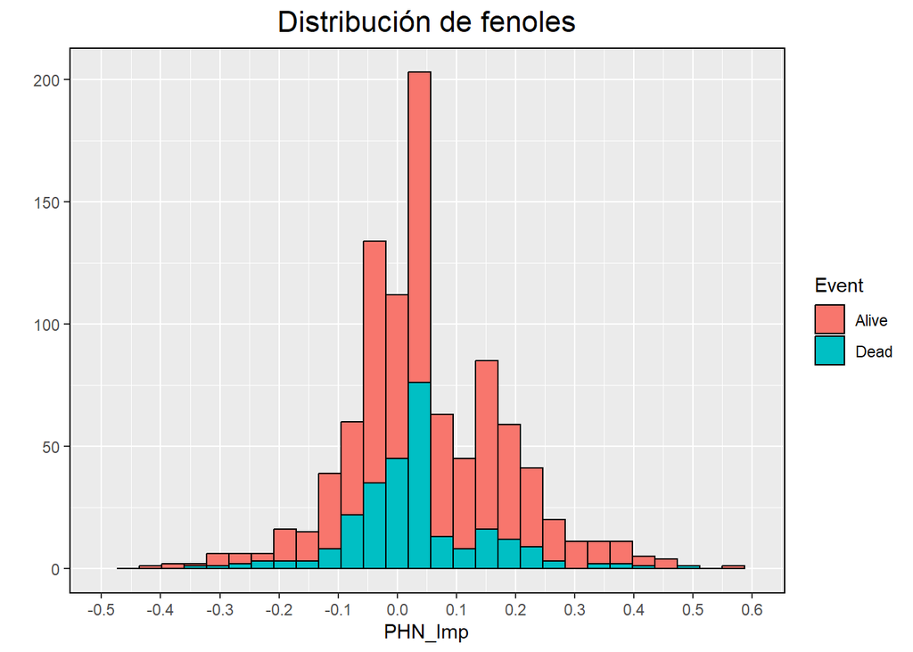

Ninguno sigue una distribución normal, por lo que tenemos que hacer una prueba no paramétrica, en este caso, de U-Mann-Whitney para comparar los dos grupos.

```
##
##  Wilcoxon rank sum test with continuity correction
##
## data:  DeadPHN$Dead and AlivePHN$Alive
## W = 79549, p-value = 0.0009001
## alternative hypothesis: true location shift is not equal to 0
```

Se elabora la siguiente gráfica para comprobar que sí se presentan diferencias visuales notables.

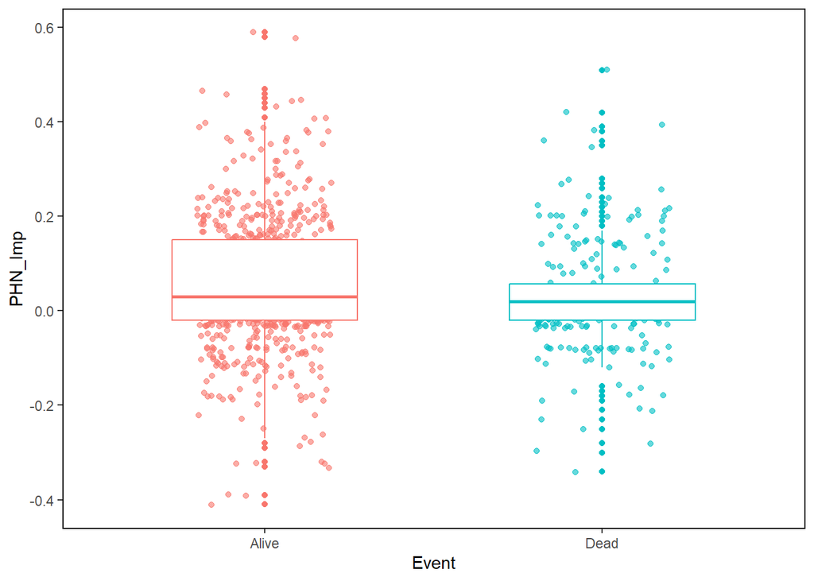

**Podemos ver diferencias notables, la concentración de fenoles es visualmente más grande en plantas vivas.**

#### Hipótesis 1.2

```r
DeadNSC <- hipo1 %>% transmute (Dead = if_else(Event == "Dead", NSC_Imp, NA)) %>%
  drop_na()
```

```r
AliveNSC <- hipo1 %>% transmute (Alive = if_else(Event == "Alive", NSC_Imp, NA)) %>%
  drop_na()
```

Para que se aprecie más fácilmente las diferencias que puedan existir entre ambos grupos, se exponen los siguientes estadícos, vemos que las medias son algo parecidas, sin embargo, en plantas vivas el NSC es de media 0,5 más alto. Más tarde comprobaremos estadíticamente si hay diferencias entre los grupos.

```
## # A tibble: 2 × 4
##   Event Media   Max   Min
##   <chr> <dbl> <dbl> <dbl>
## 1 Alive  8.26  18.2  0.44
## 2 Dead   7.76  13.8  0.67
```

Antes de empezar, tenemos que saber si las variables siguen una distribución normal. Para ello, utilizamos el test de normalidad de **Shapiro-Wilk**:

```
##
##  Shapiro-Wilk normality test
##
## data:  DeadNSC$Dead
## W = 0.98547, p-value = 0.008449
```

```
##
##  Shapiro-Wilk normality test
##
## data:  AliveNSC$Alive
## W = 0.99142, p-value = 0.0004691
```

En ambos tests se ha obtenido un p-valor inferior a 0,05, por lo que aceptamos la hipótesis alternativa, que afirma que los datos no se distribuyen normalmente.

Comprobamos, visualmente, que las variables no son normales:

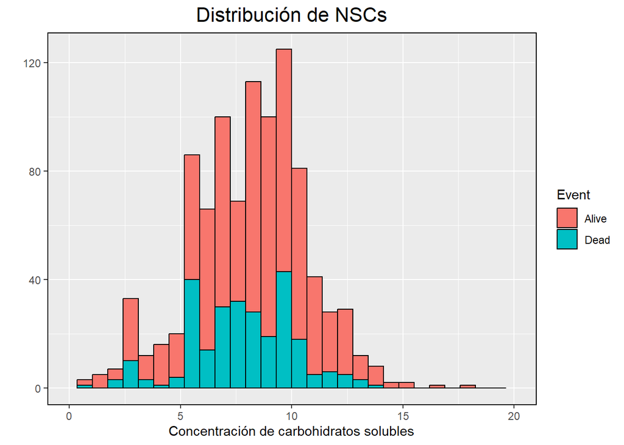

Parece que pueden seguir una distribución normal según el gráfico, probamos con el test de normalidad **Jarque Bera**, así nos aseguraremos de que los datos no siguen, de ningún modo, una distribución normal.

```
##
##  Jarque Bera Test
##
## data:  DeadNSC$Dead
## X-squared = 2.8867, df = 2, p-value = 0.2361
```

```
##
##  Jarque Bera Test
##
## data:  AliveNSC$Alive
## X-squared = 6.4419, df = 2, p-value = 0.03992
```

```
##
##  Wilcoxon rank sum test with continuity correction
##
## data:  DeadNSC$Dead and AliveNSC$Alive
## W = 81230, p-value = 0.003979
## alternative hypothesis: true location shift is not equal to 0
```

Los resultados demuestran que, estadísticamente, las plantas muertas y vivas tienen diferencias significativas en sus concentraciones de carbonos no estructurales (p < 0,05). Lo que respalda nuestra hipótesis.

Se ejecuta una gráfica para distinguir si hay una diferencia visual entre las plantas vivas y muertas. Vemos que los NSC en los vivos es mayor que en muertos, confirmando nuestra hipótesis.

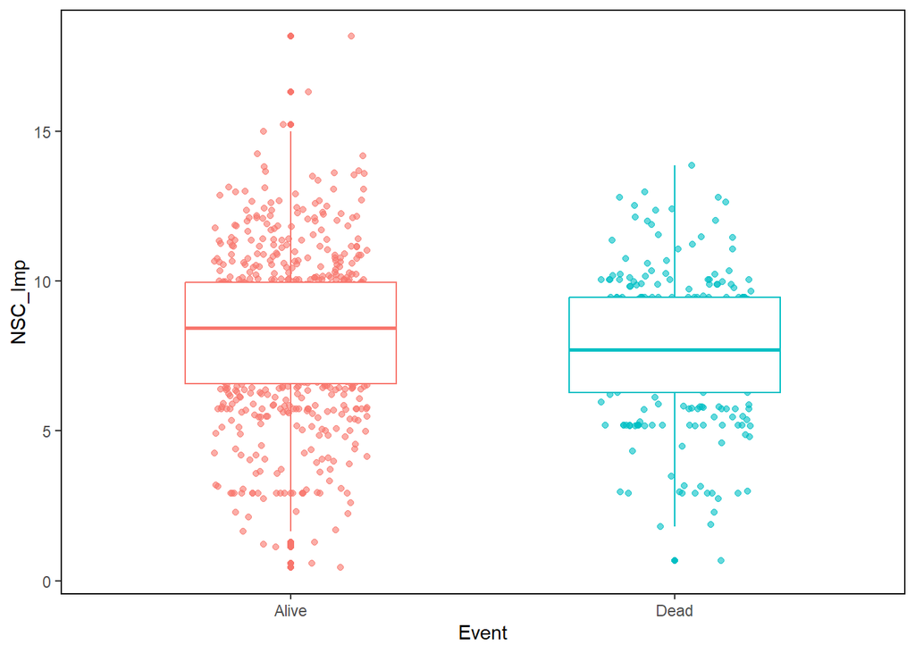

#### Comparación de las hipótesis 1.1 y 1.2

Por último, realizamos un *Permutational analysis of variance* o *Permanova* (datos no paramétricos) para asegurarnos de que hay diferencias en la concentración de fenoles y NSC entre vivas y muertas en conjunto. Este análisis nos ayudará a saber si en conjunto hay diferencias entre las variables y los grupos.

```r
adonis2( hipo1[, c("PHN_Imp","NSC_Imp")] ~ Event, data = hipo1, method = "euclidean", permutations = 99) %>%
  print()
```

```
## Permutation test for adonis under reduced model
## Permutation: free
## Number of permutations: 99
##
## adonis2(formula = hipo1[, c("PHN_Imp", "NSC_Imp")] ~ Event, data = hipo1, permutations = 99, method = "euclidean")
##           Df SumOfSqs      R2      F Pr(>F)
## Model      1     48.4 0.00789 7.6188   0.03 *
## Residual 958   6084.7 0.99211
## Total    959   6133.1 1.00000
## ---
## Signif. codes:  0 '***' 0.001 '**' 0.01 '*' 0.05 '.' 0.1 ' ' 1
```

El resultado del Permanova demuestra que se pueden diferenciar ambos grupos (p < 0.05) en cuanto las concentraciones de fenoles y NSC y cómo hemos visto las plantas vivas demuestran tener mayor cantidad de estos compuestos. Esto confirma nuestra hipótesis, los fenoles y NSC influyen positivamente a la supervivencia en sombra.

###Hipótesis 2

Para facilitar el análisis haremos un dataset con las variables de interés.

```
##   PHN_Imp NSC_Imp Event  Microbe
## 1   -0.05    5.64 Alive Combined
## 2   -0.01    6.37 Alive Combined
## 3    0.00    8.02 Alive Combined
## 4    0.13   11.11 Alive Combined
## 5    0.21   10.68 Alive Combined
## 6    0.08    8.68 Alive Combined
```

Para verificar qué tan diferentes son los grupos, a primera vista, recurrimos a unos estadísticos básicos, y vemos que, de media, hay más fenoles en el tratamiento con tan sólo **AMF**, pero, en general, son bastante parecidos en concentración.

#### Hipótesis 2.1

```
## # A tibble: 4 × 4
##   Microbe  Media   Max   Min
##   <chr>    <dbl> <dbl> <dbl>
## 1 Combined 0.186  0.71 -0.12
## 2 Control  0.174  0.68 -0.29
## 3 Large    0.194  0.59 -0.32
## 4 Small    0.118  0.57 -0.41
```

Visualmente, vemos que el tratamiento que tienen los AMF es el que tiene más fenoles, algo que no concuerda con nuestra hipótesis, basada en el artículo. Aun así, lo seguiremos comprobando más adelante.

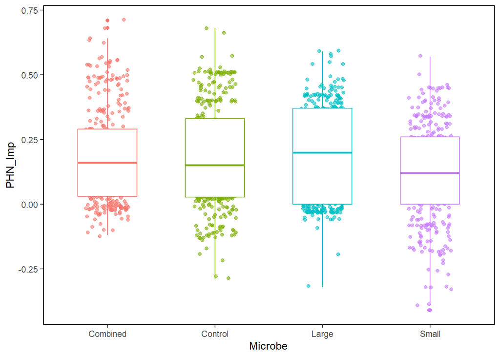

Ejecutamos un *Permanova* (datos no paramétricos) para asegurarnos de que sí hay diferencias en la concentración de fenoles entre los tratamientos.

```r
adonis2( hipo2$PHN_Imp ~ Microbe, data = hipo2, method = "euclidean" # Utilizamos este método porque es el más indicado para datos negativos (PHN_Imp)
         , permutations = 99) %>% print()
```

```
## Permutation test for adonis under reduced model
## Permutation: free
## Number of permutations: 99
##
## adonis2(formula = hipo2$PHN_Imp ~ Microbe, data = hipo2, permutations = 99, method = "euclidean")
##            Df SumOfSqs      R2      F Pr(>F)
## Model       3    1.222 0.02465 11.879   0.01 **
## Residual 1410   48.369 0.97535
## Total    1413   49.591 1.00000
## ---
## Signif. codes:  0 '***' 0.001 '**' 0.01 '*' 0.05 '.' 0.1 ' ' 1
```

Podemos ver que hay diferencias significativas entre los grupos (p-valor < 0,05), lo que confirma que, en cuanto a la concentración de fenoles, los tratamientos muestran diferencias. Y es el tratamiento con AMF el que más fenoles tiene, según las pruebas anteriores.

#### Hipótesis 2.2

Ahora haremos lo mismo, pero con los NSC, para comprobar nuestra hipótesis:

```
## # A tibble: 4 × 4
##   Microbe  Media   Max   Min
##   <chr>    <dbl> <dbl> <dbl>
## 1 Combined 10.7   22.6  0.58
## 2 Control  11.4   21.3  4.37
## 3 Large     9.11  18.5  0.44
## 4 Small     9.53  17.4  2.01
```

Vemos que quienes tienen mayor concentración de media de NSC son las muestras con el tratamiento control, lo cual, contradice nuestra hipótesis.

Hacemos un gráfico para ver las diferencias visuales entre los tratamientos, y observamos que el tratamiento control es el que más NSC tiene.

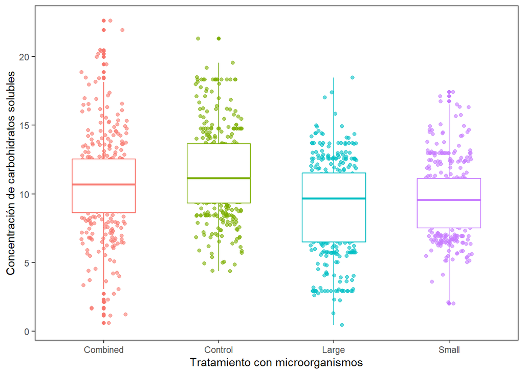

A continuación, hacemos un **Permanova** (NSC sigue siendo no paramétrica) para comprobar si hay diferencias significativas entre la concentración de NSC y los tratamientos.

```r
adonis2( hipo2$NSC_Imp ~ Microbe, data = hipo2, method = "euclidean", permutations = 99) %>% print()
```

```
## Permutation test for adonis under reduced model
## Permutation: free
## Number of permutations: 99
##
## adonis2(formula = hipo2$NSC_Imp ~ Microbe, data = hipo2, permutations = 99, method = "euclidean")
##            Df SumOfSqs      R2      F Pr(>F)
## Model       3   1221.1 0.07744 39.452   0.01 **
## Residual 1410  14547.5 0.92256
## Total    1413  15768.6 1.00000
## ---
## Signif. codes:  0 '***' 0.001 '**' 0.01 '*' 0.05 '.' 0.1 ' ' 1
```

El p-valor es menor que 0,05, por lo que hay diferencias entre los tratamientos, en base a los NSC. Y es el tratamiento control el que más tiene, según las pruebas anteriores.

#### Comparación de hipótesis 2.1 y 2.2.

Cómo último paso, haremos un **Permanova** para ver si, en conjunto, (con fenoles y NSC) los tratamientos son estadíticamente diferentes.

```r
adonis2( hipo2[, c("PHN_Imp","NSC_Imp")] ~ Microbe, data = hipo2, method = "euclidean", permutations = 99) %>% print()
```

```
## Permutation test for adonis under reduced model
## Permutation: free
## Number of permutations: 99
##
## adonis2(formula = hipo2[, c("PHN_Imp", "NSC_Imp")] ~ Microbe, data = hipo2, permutations = 99, method = "euclidean")
##            Df SumOfSqs      R2      F Pr(>F)
## Model       3   1222.3 0.07727 39.361   0.01 **
## Residual 1410  14595.9 0.92273
## Total    1413  15818.2 1.00000
## ---
## Signif. codes:  0 '***' 0.001 '**' 0.01 '*' 0.05 '.' 0.1 ' ' 1
```

Podemos comprobar que, efectivamente, los diferentes tratamientos muestran diferencias notables (p < 0.05).

**Tercera hipótesis** A continuación, comprobaremos si los tratamientos *large* y *small* son diferentes entre sí, ya que son los tratamientos en los que se basa esta hipótesis. Para ello, creamos un nuevo dataset donde filtraremos los datos de los tratamientos objetivo.

```
##   PHN_Imp NSC_Imp Event Microbe
## 1    0.38   14.98 Alive   Large
## 2   -0.03    2.95 Alive   Large
## 3    0.26   10.68 Alive   Large
## 4   -0.01    6.13 Alive   Large
## 5    0.05    7.07 Alive   Large
## 6    0.39   11.83 Alive   Large
```

Al igual que antes, al tener que hacer un **U-Mann-Whitney** (fenoles no paramétricos), tenemos que hacer dos datasets, en este caso, con los fenoles.

```r
smallPHN <- hipo2.1 %>% transmute (small = if_else(Microbe == "Small", PHN_Imp, NA)) %>%
  drop_na()
```

```r
largePHN <- hipo2.1 %>% transmute (large = if_else(Microbe == "Large", PHN_Imp, NA)) %>%
  drop_na()
```

Hacemos el test no paramétrico de **U-Mann-Whitney** y obtenemos un p-valor inferior a 0,05, por lo que aceptamos la hipótesis alternativa, que afirma que los tratamientos son diferentes en cuanto a los fenoles.

```
##
##  Wilcoxon rank sum test with continuity correction
##
## data:  smallPHN$small and largePHN$large
## W = 50143, p-value = 1.907e-06
## alternative hypothesis: true location shift is not equal to 0
```

Ahora hacemos un gráfico donde vemos que el tratamiento *large* tiene más fenoles que el *small* (con patógenos), lo cual, contradice nuestra hipótesis.

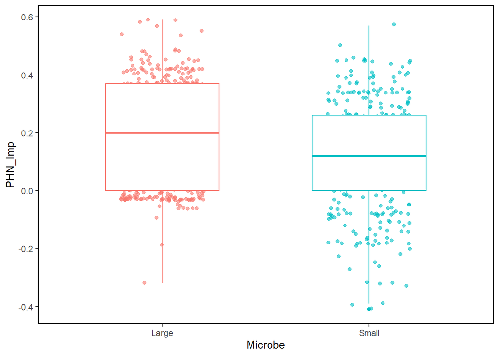

A continuación, hacemos lo mismo pero con los NSC:

Al igual que antes al tener que hacer un **U-Mann-Whitney** (fenoles no paramétricos) tenemos que hacer dos datasets, en este caso con los NSC.

```r
smallNSC <- hipo2.1 %>% transmute (small = if_else(Microbe == "Small", NSC_Imp, NA)) %>%
  drop_na()
```

```r
largeNSC <- hipo2.1 %>% transmute (large = if_else(Microbe == "Large", NSC_Imp, NA)) %>%
  drop_na()
```

Hacemos el test no paramétrico de **U-Mann-Whitney** y obtenemos un p-valor superior a 0.05, por lo que aceptamos la hipótesis nula. Esto implica que los tratamientos no son diferentes en cuanto los NSC, es decir, los NSC no cambian significativamente entre los tratamientos con patógenos y AMF.

```
##
##  Wilcoxon rank sum test with continuity correction
##
## data:  smallNSC$small and largeNSC$large
## W = 65672, p-value = 0.3628
## alternative hypothesis: true location shift is not equal to 0
```

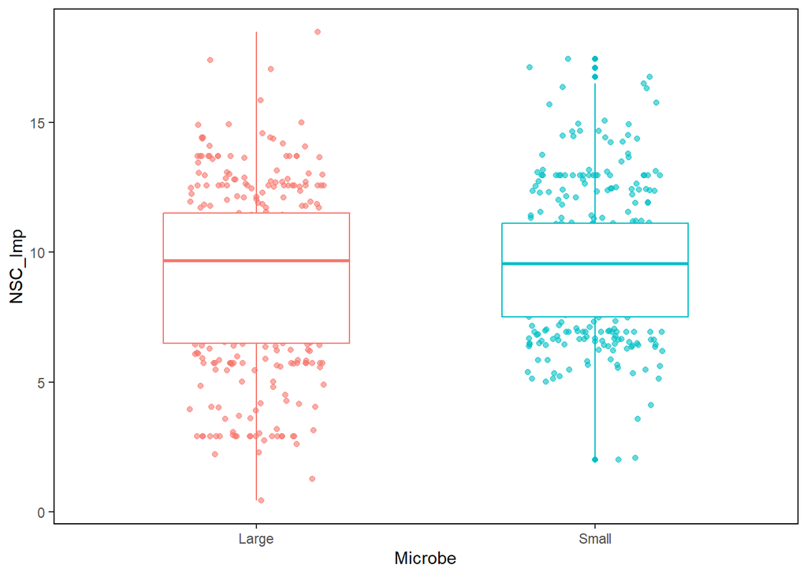

Finalmente, haremos una **Correlación de Spearman** (por ser datos no normales) para saber qué relación tienen las variables *AMF_Imp* con *NSC_Imp* y *PHN_Imp*. *AMF_Imp* es el porcentaje de inclusiones de hongos micorrízicos arbusculares en las raíces de las plantas, pues según el artículo, en presencia de estos AMF, las plantas presentan más *NSC_Imp*, algo que comprobaremos ahora. También lo hacemos con *PHN_IMP* (fenoles), ya que en los análisis anteriores, el tratamiento con AMF tuvo más fenoles.

Primero lo hacemos con los fenoles y vemos que tiene una correlación débil y positiva. Lo que quiere decir que cuantos más AMF, más fenoles.

```
##   Correlacíon entre fenoles y porcentaje de AMF
## 1                                     0.2107569
```

En el gráfico podemos ver esta relación de los datos y cómo aumentan los fenoles con los datos.

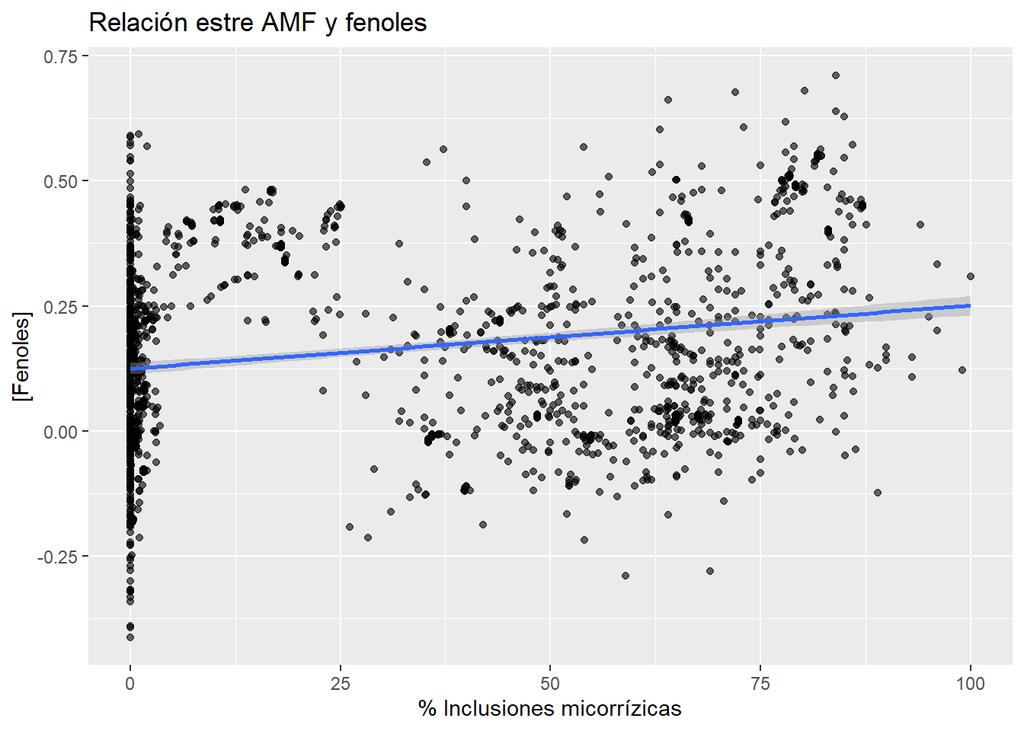

Cómo respaldaba nuestra hipótesis, hay una relación positiva entre los AMF y la concentración de NSC, aunque no es muy fuerte.

```
##   Correlacíon entre NSC y porcentaje de AMF
## 1                                 0.4285633
```

En el gráfico podemos ver esta relación de los datos y cómo aumenta el NSC con los datos.

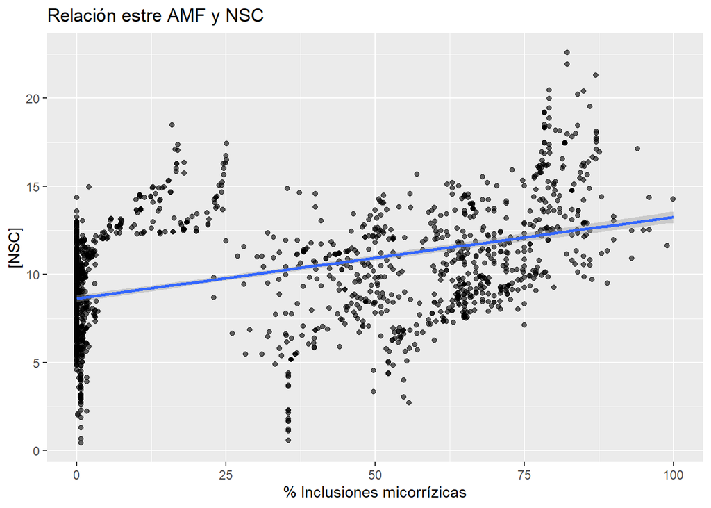

### Bibliografía

Oksanen, Jari, Gavin L. Simpson, F. Guillaume Blanchet, Roeland Kindt, Pierre Legendre, Peter R. Minchin, R. B. O’Hara, et al. 2024. *Vegan: Community Ecology Package*. https://github.com/vegandevs/vegan.

R Core Team. 2024. *R: A Language and Environment for Statistical Computing*. Vienna, Austria: R Foundation for Statistical Computing. https://www.R-project.org/.

Trapletti, Adrian, and Kurt Hornik. 2024. *Tseries: Time Series Analysis and Computational Finance*. https://CRAN.R-project.org/package=tseries.

Wickham, Hadley. 2016. *Ggplot2: Elegant Graphics for Data Analysis*. Springer-Verlag New York. https://ggplot2.tidyverse.org.

Wickham, Hadley, Mara Averick, Jennifer Bryan, Winston Chang, Lucy D’Agostino McGowan, Romain François, Garrett Grolemund, et al. 2019. “Welcome to the tidyverse.” *Journal of Open Source Software* 4 (43): 1686. https://doi.org/10.21105/joss.01686.

Wickham, Hadley, Winston Chang, Lionel Henry, Thomas Lin Pedersen, Kohske Takahashi, Claus Wilke, Kara Woo, Hiroaki Yutani, Dewey Dunnington, and Teun van den Brand. 2024. *Ggplot2: Create Elegant Data Visualisations Using the Grammar of Graphics*. https://ggplot2.tidyverse.org.

Wickham, Hadley, Romain François, Lionel Henry, Kirill Müller, and Davis Vaughan. 2023. *Dplyr: A Grammar of Data Manipulation*. https://dplyr.tidyverse.org.

Wood, Katherine EA, Richard K Kobe, and Sarah McCarthy-Neumann. 2023. “Tree Seedling Shade Tolerance Arises from Interactions with Microbes and Is Mediated by Functional Traits.” *Frontiers in Ecology and Evolution* 11: 1224540.

Xie, Yihui. 2014. “Knitr: A Comprehensive Tool for Reproducible Research in R.” In *Implementing Reproducible Computational Research*, edited by Victoria Stodden, Friedrich Leisch, and Roger D. Peng. Chapman; Hall/CRC.

———. 2015. *Dynamic Documents with R and Knitr*. 2nd ed. Boca Raton, Florida: Chapman; Hall/CRC. https://yihui.org/knitr/.

———. 2024. *Knitr: A General-Purpose Package for Dynamic Report Generation in r*. https://yihui.org/knitr/.